# Milestone-Report

Mohammad Ali Shaaban

January 8, 2019

# Introductions

The goal of this project is just to display that you’ve gotten used to working with the data and that you are on track to create your prediction algorithm. Please submit a report on R Pubs (http://rpubs.com/) that explains your exploratory analysis and your goals for the eventual app and algorithm. This document should be concise and explain only the major features of the data you have identified and briefly summarize your plans for creating the prediction algorithm and Shiny app in a way that would be understandable to a non-data scientist manager. You should make use of tables and plots to illustrate important summaries of the data set. The motivation for this project is to:

1. Demonstrate that you’ve downloaded the data and have successfully loaded it in.
2. Create a basic report of summary statistics about the data sets.
3. Report any interesting findings that you amassed so far.
4. Get feedback on your plans for creating a prediction algorithm and Shiny app.

# Downloading & Loading Data :

```r
library(tidytext)
library(tidyr)
library(dplyr)
```

```r
library(ggplot2)
library(qdapRegex)
wd <- getwd()
f <- "Coursera-SwiftKey.zip"
if (!dir.exists("Coursera-SwiftKey")) {
    url <- "https://d396qusza40orc.cloudfront.net/dsscapstone/dataset/Coursera-SwiftKey.zip"
    if (!file.exists("Coursera-SwiftKey.zip")) {
        download.file(url, destfile = "Coursera-SwiftKey.zip", method = "curl")
        unzip("Coursera-SwiftKey.zip")
        download.file(url, file.path(wd, f), method = "curl")
        unzip(f)
    }
}
```

# basic report of summary statistics

Reading blogs, twitter, and news files

```r
blogs_file<-"en_US/en_US.blogs.txt"
twitter_file<-"en_US/en_US.twitter.txt"
news_file<-"en_US/en_US.news.txt"

blogs <- readLines(blogs_file, warn = FALSE, encoding = "UTF-8", skipNul = TRUE)
twitter <- readLines(twitter_file, warn = FALSE, encoding = "UTF-8", skipNul = TRUE)
news <- readLines(news_file, warn = FALSE, encoding = "UTF-8", skipNul = TRUE)
```

# Summarizing the number of lines and words:

## blogs:–

```r
## blogs number of lines
length(blogs)
```

```
## [1] 899288
```

```r
## blogs number of words
sum(sapply(gregexpr("[[:alpha:]]+", blogs), function(x) sum(x > 0)))
```

```
## [1] 37873860
```

## twitter:–

```r
## twitter number of lines
length(twitter)
```

```
## [1] 2360148
```

```r
## twitter number of words
sum(sapply(gregexpr("[[:alpha:]]+", twitter), function(x) sum(x > 0)))
```

```
## [1] 30555611
```

## news:--

```r
## news number of lines
length(news)
```

```
## [1] 77259
```

```r
## news number of words
sum(sapply(gregexpr("[[:alpha:]]+", news), function(x) sum(x > 0)))
```

```
## [1] 2662070
```

# Exploratory Analysis:–

## sample of data: 5% of each dataset:

```r
set.seed(12345)
twitter_sample  <- sample(twitter, length(twitter) * 0.05, replace = FALSE)
blogs_sample    <- sample(blogs, length(blogs) * 0.05, replace = FALSE)
news_sample     <- sample(news, length(news) * 0.05, replace = FALSE)
data_sample = c(twitter_sample, blogs_sample, news_sample)
```

# Cleaning Data:

```r
# 1. Remove lines with unidentify characters
NotKnown <- grep("NotKnown", iconv(data_sample, "latin1", "ASCII", sub="NotKnown"))
data_sample <- data_sample[-NotKnown]
# doing some simple cleaning
data_sample <- gsub("&amp", "", data_sample)
data_sample <- gsub("RT :|@[a-z,A-Z]*: ", "", data_sample) # remove tweets
data_sample <- gsub("@\\w+", "", data_sample)
data_sample <- gsub("[[:digit:]]", "", data_sample) # remove digits
data_sample <- gsub(" #\\S*","", data_sample)  # remove hash tags
data_sample <- gsub(" ?(f|ht)tp(s?)://(.*)[.][a-z]+", "", data_sample) # remove url
data_sample <- rm_white(data_sample) # remove extra spaces
```

# dataframe for n-gram analysis:

```r
data_sample_df <- data_frame(line = 1:length(data_sample),
                             text = data_sample)
```

# Unigram:

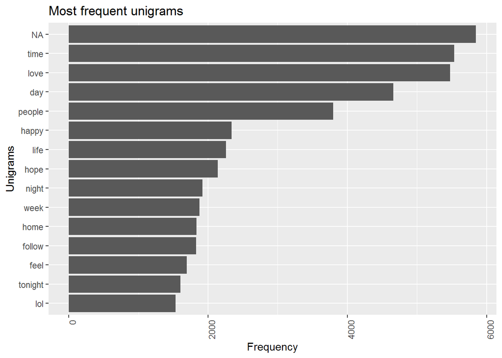

```r
UnigramFreq <- data_sample_df %>%
    unnest_tokens(unigram, text, token = "ngrams", n = 3) %>%
    separate(unigram, c("word1"), sep = " ",
             extra = "drop", fill = "right") %>%
    filter(!word1 %in% stop_words$word) %>%
    unite(unigram, word1, sep = " ") %>%
    count(unigram, sort = TRUE)

ggplot(head(UnigramFreq,15), aes(reorder(unigram,n), n)) +
    geom_bar(stat="identity") + coord_flip() +
    xlab("Unigrams") + ylab("Frequency") +
    ggtitle("Most frequent unigrams") +
    theme(axis.text.x=element_text(angle=90, hjust=1))
```